# Exploring the BRFSS data

Saikrithika A. Gandhi

```r
nrow(brfss2013)
```

```
## [1] 491775
```

```r
ncol(brfss2013)
```

```
## [1] 330
```

The dataset contains 491775 observations of 330 variables.

## Research Question

The question I want to explore is to find whether people who live in different metropolitan areas are affected by asthma differently. The variable `mscode` lists the location of the respondent. The variable `asthnow` lists whether the person currently has asthma. We will subset the dataset to only the columns of interest, i.e., `mscode` and `asthnow`, then filter out all the missing values from the variables for easy handling and manipulation.

```r
asthma_dataset <- brfss2013 %>%
  select(mscode, asthnow) %>%
  filter(!is.na(mscode)) %>% filter(!is.na(asthnow))
```

[output not shown]

The dataset has 45,240 observations where both region and asthma were reported. This is a reasonable sized dataset.

The metropolitan area is grouped into five categories, i.e., people who live in the center city of an MSA, outside the center city, inside a suburban county of MSA, In an MSA with no center city and not in MSA. The percentage of people affected by asthma is calculated for each location.

```r
asthma_result <- asthma_dataset %>%
  group_by(mscode) %>%
  summarise(asthma_percentage = sum(asthnow == "Yes") * 100 / n()) %>%
  arrange(desc(asthma_percentage))


asthma_result
```

```
## # A tibble: 5 x 2
##   mscode                                                  asthma_percenta…
##   <fct>                                                              <dbl>
## 1 Not in an MSA                                                       73.5
## 2 Inside a suburban county of the MSA                                 72.2
## 3 Outside the center city of an MSA but inside the count…             71.7
## 4 In the center city of an MSA                                        70.8
## 5 In an MSA that has no center city                                   70.8
```

We will plot the result to visualise and check if there is a significant percentage of people being affected from asthma who live in different areas of metropolitan. Especially for those who live inside and outside MSA.

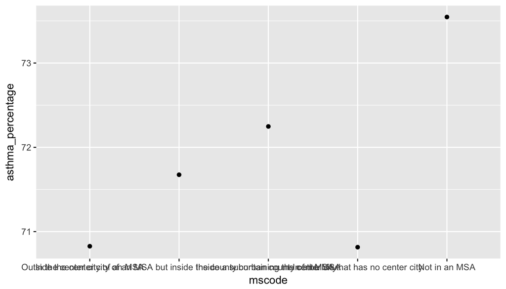

```r
ggplot(asthma_result, aes(x=mscode, y= asthma_percentage)) + geom_point()
```

We will next explore whether there is statistical support for this thesis.

# Difference of two proportions – Theory

Difference of two proportions is method for an inference with categorical data. There are two tests:

1. Confidence intervals
2. Hypothesis test The formulae are slightly different.

Two conditions should apply

1. Each proportion separately follows the normal model
2. two samples are independent of each other.

**Standard error**
$$SE_{p_1 - p_2} = \sqrt{ SE_{p_1}^2 + SE_{p_2}^2 } =
\sqrt{ \frac{p_1 (1-p_1)}{n_1} + \frac{p_2 (1-p_2)}{n_2} }$$

# Confidence Interval

Let us consider `Not in MSA` as rural areas and all other categories as `non-rural` areas.

1. Create a dataset with column which has regions: rural, urban.

```
## # A tibble: 2 x 4
##   region asthma_count total_count proportion
##   <chr>         <int>       <int>      <dbl>
## 1 rural         11521       15665      0.735
## 2 urban         21110       29575      0.714
```

2. Calculate the proportion for asthma in Urban and rural

```r
# n1(Total count in urban)
num_urban <- asthma_not_urban[2,]$total_count
# p1 (proportion of asthma in urban)
prop_urban <- asthma_not_urban[2,]$asthma_count/num_urban

# n2(Total count in rural)
num_rural<- asthma_not_urban[1,]$total_count
# p2(proportion of asthma in rural)
prop_rural <- asthma_not_urban[1,]$asthma_count/num_rural
```

3. Standard error to find CI

```r
failure_urban <- (1-prop_urban)
failure_rural <-(1-prop_rural)

std_error <-sqrt(
      (prop_urban* failure_urban)/num_urban +
      (prop_rural* failure_rural)/num_rural
    )
```

4. Confidence interval

```r
#conf_interval
lower_95  <- prop_rural - prop_urban - qnorm(.975) * std_error
upper_95  <- prop_rural - prop_urban + qnorm(.975) * std_error

paste0(lower_95 *100, ",  ", upper_95 * 100)
```

```
## [1] "1.30660373641975,  3.02993428668068"
```

5. **Conclusion**

There is a difference between the proportion of reported asthma rural and non-rural areas. *We are 95% confident that there is a difference in proportion between rural and non-rural areas to the extent of (1.3066037, 3.0299343)*

# Hypothesis testing:

We take the null hypothesis to be that there is no difference between rural and non-rural areas. That is,

**H_0**: proportion of asthma in rural areas - proportion of asthma in non-rural areas = 0  
**HA**: proportion of asthma in rural areas - proportion of asthma in non-rural areas != 0

$p_1 - p_2 = 0$ is another way of saying $p_1 = p_2$.

## Pooled proportion

In the case of hypothesis testing we will use *pooled proportion* to calculate the p-value. The intuition for Pooled proportion is the following. We take the proportion of asthma in the entire population. This is our best estimate of proportion of asthma in rural as well as non-rural areas. In other words, we assume that both rural and non-rural areas have the same proportion of asthma.

1. Calculate pooled proportion

```r
pooled_proportion<- sum(asthma_not_urban$asthma_count) /
                  sum(asthma_not_urban$total_count)
```

2. Standard Error using pooled proportion

```r
# standard error using pooled proportion
std_error_pooled <-sqrt(
      (pooled_proportion * (1-pooled_proportion))/num_urban +
      (pooled_proportion * (1-pooled_proportion))/num_rural
    )
```

3. Compute z-score

```r
# Z-score
point_estimate <- (prop_urban - prop_rural)
z_estimate <- (point_estimate - 0)/std_error_pooled

z_estimate
```

```
## [1] -4.893803
```

```r
p_value = 2*pnorm(z_estimate)

p_value
```

```
## [1] 9.890562e-07
```

4. **Conclusion**

Since p-value 9.890561710^{-7} is less than significance level of 0.5 we reject the null hypothesis. We conclude that there is a significant difference between the rural and non-rural proportions of asthma.

# Learnings from this exercise

1. Calculations for confidence interval
2. Calculations for hypothesis testing using pooled proportion.
3. Since we are using the same inference framework, the confidence interval and hypothesis testing agree. That is there is a difference between rural and non-rural groups in the proportion of asthma incidence.